# Intro to R

## Viewing Matrices and Data Frames

You can use the `View` function to open a spreadsheet-style view of a matrix or data frame. Use the `View` function, or double-click on the name of the object in the Environment tab in the upper right window in RStudio.

You can also use the `head` function to see the first 6 (by default) rows of a matrix or data frame:

```r
head(df)
```

```
##   id color     score
## 1  1   red 0.4537281
## 2  2   red 0.3267524
## 3  3   red 0.9654153
## 4  4 green 0.7074819
## 5  5 green 0.6445426
## 6  6 green 0.3898285
```

You can get dimensions with:

```r
dim(y)
```

```
## [1] 5 5
```

```r
dim(df)
```

```
## [1] 20  3
```

```r
nrow(y)
```

```
## [1] 5
```

```r
ncol(df)
```

```
## [1] 3
```

The `length` of a matrix is the number of elements. The `length` of a data frame is the number of columns:

```r
length(y)
```

```
## [1] 25
```

```r
length(df)
```

```
## [1] 3
```

## Lists

Lists are the other major data structure. An element of a list can hold any other object, including another list. You can keep multi-dimensional and ragged data in R using lists. See other resources listed at the bottom of this file for information on lists.

# Workspace Management

List objects in your workspace

```r
ls()
```

```
##  [1] "cbPalette"  "color"      "colors"     "df"         "gapminder"
##  [6] "id"         "myVariable" "notes"      "params"     "schooldata"
## [11] "score"      "tmp"        "vals"       "w"          "x"
## [16] "y"
```

Or look in the Environment window in the upper right in RStudio.

You can remove objects from your workspace:

```r
myVariable <- 1:10
rm(myVariable)
```

Or clear your entire workspace (can’t be undone):

```r
rm(list = ls())
```

You can also clear your workspace by clicking on the broom in the Environment window in RStudio.

You can save an image of your entire workspace to pick up where you left off in another session of R (this is what R asks you if you want to do when you quit). Workspace files are saved with the extension .RData.

```r
save.image("20170112.RData")
```

You can load this file later with the `load` function

```r
load("20170112.RData")
```

Note that `load` will overwrite any objects already in your workspace that have the same names as objects in the file you are loading.

# Packages

Much of R’s power comes from contributed packages. You can install and manage packages using the Packages tab in the bottom right window in RStudio. Or you can install packages with a command:

```r
install.packages("dplyr")
```

CRAN (Comprehensive R Archive Network) is the name of the package repository. There are [mirrors](https://cran.r-project.org/mirrors.html) around the world.

If you have trouble or get errors when trying to install a package, you might need to specify the repository mirror to download from:

```r
install.packages("ggplot2", repos="http://cran.wustl.edu/")
```

# Reading and Writing Data

Before reading or writing files, it’s often useful to set the working directory first so that you don’t have specify complete file paths.

You can go to the Files tab in the bottom right window in RStudio and find the directory you want. Then under the More menu, there is an option to set the current directory as the working directory. Or you can use the `setwd` command like:

```r
setwd("~/training/rtoolkit")
getwd()
```

## Reading

### Basics

Read in a csv file and save it as a data frame with a name. The example uses a url, but you can use a local file the same way.

```r
gapminder<-read.csv("https://nuitrcs.github.io/staticfiles/gapminder5.csv")
```

You could also use the Import Dataset option in the Environment tab in the top right window in RStudio.

Looking at the help for `read.csv`, there are a number of different options and different function calls. `read.table`, `read.csv`, and `read.delim` all work in the same basic way and take the same set of arguments, but they have different defaults. They will all read in a plain text, delimited file into a data frame though. Key options to pay attention to include:

- `header`: whether the first row of the file has the names of the columns
- `sep`: the separator used (comma, tab (enter as `\t`), etc) in the file
- `na.strings`: how is missing data encoded in your file? “NA” are treated as missing by default; blanks are treated as missing by default in everything but character data.
- `stringsAsFactors`: should strings (text data) be converted to factors or kept as is? Example of this below.

### Text Data

The `stringsAsFactors` option, by default, will convert text data columns to factors. Sometimes you don’t want this. Let’s read in some data using the default options:

```r
schooldata<-read.csv("https://nuitrcs.github.io/staticfiles/allstudents.csv")
```

Look at the structure by looking at the object in the Environment view in the upper right corner of RStudio, or type:

```r
str(schooldata)
```

```
## 'data.frame':    888 obs. of  12 variables:
##  $ courseid       : int  304 304 304 304 304 304 304 304 304 304 ...
##  $ title          : Factor w/ 27 levels "Decision Analysis",..: 21 21 21 21 21 21 21 21 21 21 ...
##  $ startdate      : Factor w/ 13 levels "","2014-1-10",..: 11 11 11 11 11 11 11 11 11 11 ...
##  $ grade          : num  3.3 2.3 1.6 3 1.3 2.2 2.4 2.5 1.6 1.8 ...
##  $ instructorid   : int  16 16 16 16 16 16 16 16 16 16 ...
##  $ instructorfirst: Factor w/ 20 levels "Adam","Ali","Amy",..: 1 1 1 1 1 1 1 1 1 1 ...
##  $ instructorlast : Factor w/ 20 levels "Ahmadpour","Allen",..: 16 16 16 16 16 16 16 16 16 16 ...
##  $ instructortitle: Factor w/ 7 levels "Assistant Professor",..: 6 6 6 6 6 6 6 6 6 6 ...
##  $ studentid      : int  4 5 6 7 13 19 21 23 30 33 ...
##  $ gender         : Factor w/ 3 levels "","F","M": 2 1 1 2 2 2 3 2 2 2 ...
##  $ age            : int  17 21 16 18 18 21 22 20 21 21 ...
##  $ admissionyear  : int  2010 2010 2011 2011 2010 2010 2008 2009 2010 2010 ...
```

The instructor names were made into factors. This doesn’t make much sense, especially because names are split across two columns. And it can introduce problems like those noted in the (factors section)[#factors] above.

Make text not be treated as factors with an option to `read.csv` called `stringsAsFactors`. The option `strip.white` will clean off extra white space from the names if there is any.

So a new read command:

```r
schooldata<-read.csv("https://nuitrcs.github.io/staticfiles/allstudents.csv", stringsAsFactors=FALSE, strip.white=TRUE, na.strings=c("NA", ""))
```

The option `na.strings` is needed now because while blanks are treated as missing by default in numeric fields (which includes factors), they aren’t by default missing for character data.

## Writing

You will often want to save your work in R as well. There are a few different ways to save:

### Writing a data file

To write a CSV, there are equivalent `write.csv` and `write.table` functions to the read. The one trick is that you usually want to NOT write row.names. You also may need to be careful about quotes: for the gapminder data, there any complicated strings (text), so there’s no need to quote them.

```r
write.csv(gapminder, file="gapmindercopy.csv", row.names=FALSE, quote=FALSE)
```

### Saving R objects

You can use the `save` function to save multiple objects together in a file. The standard file extension to use is `.RData`. Example:

```r
save(gapminder, schooldata, file = "workshopobjects.RData")
```

To later load in saved data, use the `load` function:

```r
load("workshopobjects.RData")
```

# Tidyverse

Hadley Wickham, a prolific R developer, and his colleagues have made a number of R packages that try to make common tasks easier. The use of these packages is becoming standard for some applications. In the data manipulation sections that follow, options using these “tidyverse” functions are shown along with options using base R functionality.

To install, use the Packages tab in the lower right window in RStudio, or command:

```r
install.packages(c("tidyverse", "lubridate"))
```

“tidyverse” is a convenience package that loads a bunch of related packages

Then load them:

```r
library(tidyverse)
library(lubridate)
```

The `dplyr` package adds a new type of command: `%>%`. This is like a pipe `|` from the command line environment of a computer. It takes the output of the thing on the left of the pipe and sends it as the first parameter to the command on the right of the pipe. You can string multiple commands together this way. `dplyr` has a variety of “verbs” – ways to manipulate data. For example, `select`, `filter`, `arrange`, `mutate`, and `summarize`. There will be some examples of this below. You don’t have to use `dplyr`, but you should know it exists and recognize commands in it.

# Exploring Data: an example

Here’s an example of exploring and cleaning up some data using the `schooldata` data frame loaded above.

## Mutating Data

In `schooldata` the instructors’ names were split into multiple columns, and we have a date column. Make these easier to work with by combining the instructor names into a single column and making the date into a `Date` type:

```r
schooldata$instructorname <- paste(schooldata$instructorfirst, schooldata$instructorlast)
```

The equivalent command using `dplyr` instead is:

```r
schooldata<-mutate(schooldata, instructorname=paste(instructorfirst, instructorlast))
```

Currently the startdate variable is a character vector:

```r
typeof(schooldata$startdate)
```

```
## [1] "character"
```

This isn’t very easy to work with. Make the date column a `Date` type.

```r
schooldata$startdate<-as.Date(schooldata$startdate)
```

Converting to a date will make plotting easier, and you can do arithmatic and logic with the date if needed.

The above worked because the date was nicely formatted in YYYY-MM-DD format. What about other formats of dates? The `lubridate` package makes working with them easy. It has a series of functions like `ymd` and `dmy` that specify the order that our date fields are in, and then it figures out how to parse them correctly. It can also handle time. In this case, we could use `ymd`:

```r
schooldata$startdate<-ymd(schooldata$startdate)
```

## Summarizing

One useful function is `summary`:

```r
summary(schooldata)
```

```
##     courseid        title             startdate              grade
##  Min.   :201.0   Length:888         Min.   :2014-01-07   Min.   :1.000
##  1st Qu.:305.8   Class :character   1st Qu.:2014-09-15   1st Qu.:1.900
##  Median :325.0   Mode  :character   Median :2015-01-07   Median :2.600
##  Mean   :323.6                      Mean   :2015-01-20   Mean   :2.609
##  3rd Qu.:381.0                      3rd Qu.:2015-09-20   3rd Qu.:3.400
##  Max.   :393.0                      Max.   :2016-03-09   Max.   :4.000
##                                     NA's   :32
##   instructorid    instructorfirst    instructorlast     instructortitle
##  Min.   : 0.000   Length:888         Length:888         Length:888
##  1st Qu.: 4.000   Class :character   Class :character   Class :character
##  Median :10.000   Mode  :character   Mode  :character   Mode  :character
##  Mean   : 9.815
##  3rd Qu.:17.000
##  Max.   :21.000
##
##    studentid        gender               age        admissionyear
##  Min.   : 0.00   Length:888         Min.   :16.00   Min.   :2007
##  1st Qu.:26.00   Class :character   1st Qu.:18.00   1st Qu.:2008
##  Median :48.00   Mode  :character   Median :20.00   Median :2010
##  Mean   :48.76                      Mean   :19.51   Mean   :2009
##  3rd Qu.:73.00                      3rd Qu.:21.00   3rd Qu.:2011
##  Max.   :98.00                      Max.   :24.00   Max.   :2011
##                                     NA's   :16
##  instructorname
##  Length:888
##  Class :character
##  Mode  :character
##
##
##
##
```

Consider the summary of `age`. The summary of the age in this case isn’t very helpful because there are multiple observations for each student:

```r
table(schooldata$studentid)
```

```
##
##  0  1  2  3  4  5  6  7  8  9 10 11 12 13 14 15 16 17 18 19 20 21 22 23 24
## 11  7  7  9 11  9  8  8 12  7 12  9  5  9  5 12 12  9  9  9  6  9  6  6  6
## 25 26 27 28 29 30 31 32 33 34 35 36 37 38 39 40 41 42 43 44 45 46 47 48 49
##  6 14  9  8  9  9  9 10  7  7 13 14  6 12  8 12  8  7 11  6 10 10 13 14  5
## 50 51 52 53 54 55 56 57 58 59 60 61 62 63 64 65 66 67 68 69 70 71 72 73 74
##  7 12  9 10  7  8 13 10 11 10  9  8  7 11 10 10 11  9 10 10  5 12  5  8  9
## 75 76 77 78 79 80 81 82 83 84 85 86 87 88 89 90 91 92 93 94 95 96 97 98
##  9 11  7 12  9  8  8  5  9 11 14  8  5  7 15 10  7  8 10  9  6  8  5  6
```

Use `unique` to get a summary of age with just one observation per student.

```r
summary(unique(schooldata[,c("studentid", "age")])$age)
```

```
##    Min. 1st Qu.  Median    Mean 3rd Qu.    Max.    NA's
##   16.00   18.00   20.00   19.62   21.00   24.00       2
```

or the `dplyr` way:

```r
select(schooldata, studentid, age) %>% distinct() %>% select(age) %>% summary()
```

```
##       age
##  Min.   :16.00
##  1st Qu.:18.00
##  Median :20.00
##  Mean   :19.62
##  3rd Qu.:21.00
##  Max.   :24.00
##  NA's   :2
```

Taking just one observation per student gives a slightly different result.

Make a few tables:

```r
table(schooldata$gender, useNA="ifany")
```

```
##
##    F    M <NA>
##  512  344   32
```

```r
table(schooldata$instructorname, useNA="ifany")
```

```
##
##       Adam Terry      Ali Iravani       Amy Watson   Benjamin Allen
##               32               74               30               38
##     Bruce Banner  Charles Johnson Daniel Ahmadpour  Diego Fernandez
##               60               91               30               25
##     Gordon Howie   Hassan Caliban      Jane Wilson  Jeremy Sessions
##               71               42               43               29
##  Karen Stenowitz      Mark Warren      Mike Marion    Neil Mehrotra
##               35               28               40               27
##    Ohad Peterson          TBD TBD    Vadim Lubskey  William Wallace
##               29               93               35               36
```

Hmm…for instructors, it looks like there is as “TBD” that should perhaps be missing. You could read in the data again specifying “TBD” as a missing string, or recode the value. You could fix the individual first and last name columns, or just the new combined one created above. Just fix the combined one for now.

```r
schooldata$instructorname[schooldata$instructorname=="TBD TBD"]<-NA
```

How can you get average grade by class?

The `tapply` function is an option. It applies a function (`mean` below) to a vector (`schooldata$grade` below) based on the values of another vector (`schooldata$title` below):

```r
tapply(schooldata$grade, schooldata$title, mean)
```

```
##                           Decision Analysis
##                                    2.533333
##      Deterministic Methods and Optimization
##                                    2.580000
##           Discrete-Event Systems Simulation
##                                    2.568966
##         Economics and Finance for Engineers
##                                    2.586842
##                Engineering Entrepreneurship
##                                    2.667500
##                       Field Project Methods
##                                    2.415385
##               Industrial Engineering Design
##                                    2.648000
##       Industrial Engineering Design Project
##                                    2.589286
##       Introduction to Financial Engineering
##                                    2.637143
##  Introduction to Health Systems Engineering
##                                    2.529630
##                  Introduction to Statistics
##                                    2.347222
##          Methods, Standards and Work Design
##                                    2.971875
##                         Operations Research
##                                    2.618605
##                     Organizational Behavior
##                                    2.750000
##              Principles of Entrepreneurship
##                                    2.693333
##                                 Probability
##                                    2.652632
##          Production Planning and Scheduling
##                                    2.500000
##  Quality Improvement by Experimental Design
##                                    2.693548
##               Service Operations Management
##                                    2.655000
##                    Social Networks Analysis
##                                    2.559524
##         Statistical Methods for Data Mining
##                                    2.537500
## Statistical Methods for Quality Improvement
##                                    2.693333
##                                  Statistics
##                                    2.420833
##            Stochastic Models and Simulation
##                                    2.489655
##          Supply-Chain Modeling and Analysis
##                                    2.580000
##                          Systems Management
##                                    2.645946
##                  Systems Project Management
##                                    2.825000
```

Sort the result:

```r
sort(tapply(schooldata$grade, schooldata$title, mean), decreasing=TRUE)
```

```
##          Methods, Standards and Work Design
##                                    2.971875
##                  Systems Project Management
##                                    2.825000
##                     Organizational Behavior
##                                    2.750000
##  Quality Improvement by Experimental Design
##                                    2.693548
##              Principles of Entrepreneurship
##                                    2.693333
## Statistical Methods for Quality Improvement
##                                    2.693333
##                Engineering Entrepreneurship
##                                    2.667500
##               Service Operations Management
##                                    2.655000
##                                 Probability
##                                    2.652632
##               Industrial Engineering Design
##                                    2.648000
##                          Systems Management
##                                    2.645946
##       Introduction to Financial Engineering
##                                    2.637143
##                         Operations Research
##                                    2.618605
##       Industrial Engineering Design Project
##                                    2.589286
##         Economics and Finance for Engineers
##                                    2.586842
##      Deterministic Methods and Optimization
##                                    2.580000
##          Supply-Chain Modeling and Analysis
##                                    2.580000
##           Discrete-Event Systems Simulation
##                                    2.568966
##                    Social Networks Analysis
##                                    2.559524
##         Statistical Methods for Data Mining
##                                    2.537500
##                           Decision Analysis
##                                    2.533333
##  Introduction to Health Systems Engineering
##                                    2.529630
##          Production Planning and Scheduling
##                                    2.500000
##            Stochastic Models and Simulation
##                                    2.489655
##                                  Statistics
##                                    2.420833
##                       Field Project Methods
##                                    2.415385
##                  Introduction to Statistics
##                                    2.347222
```

or we could use `dplyr`:

```r
group_by(schooldata, title) %>% summarize(avg_grade=mean(grade)) %>% arrange(desc(avg_grade))
```

```
## # A tibble: 27 × 2
##                                          title avg_grade
##                                          <chr>     <dbl>
## 1           Methods, Standards and Work Design  2.971875
## 2                   Systems Project Management  2.825000
## 3                      Organizational Behavior  2.750000
## 4   Quality Improvement by Experimental Design  2.693548
## 5               Principles of Entrepreneurship  2.693333
## 6  Statistical Methods for Quality Improvement  2.693333
## 7                 Engineering Entrepreneurship  2.667500
## 8                Service Operations Management  2.655000
## 9                                  Probability  2.652632
## 10               Industrial Engineering Design  2.648000
## # ... with 17 more rows
```

Wait! What is a tibble? Basically, it’s a data.frame, but deals with a few annoying things about data.frames. One of these annoying things is that data.frames print their entire contents by default. For big data sets, this gets old fast. The tibble doesn’t do that. You can look at the help for tibble to see more details, but you can treat it like a data.frame.

To force printing of more rows in the result:

```r
group_by(schooldata, title) %>% summarize(avg_grade=mean(grade)) %>% arrange(desc(avg_grade)) %>% print(n=40)
```

```
## # A tibble: 27 × 2
##                                          title avg_grade
##                                          <chr>     <dbl>
## 1           Methods, Standards and Work Design  2.971875
## 2                   Systems Project Management  2.825000
## 3                      Organizational Behavior  2.750000
## 4   Quality Improvement by Experimental Design  2.693548
## 5               Principles of Entrepreneurship  2.693333
## 6  Statistical Methods for Quality Improvement  2.693333
## 7                 Engineering Entrepreneurship  2.667500
## 8                Service Operations Management  2.655000
## 9                                  Probability  2.652632
## 10               Industrial Engineering Design  2.648000
## 11                          Systems Management  2.645946
## 12       Introduction to Financial Engineering  2.637143
## 13                         Operations Research  2.618605
## 14       Industrial Engineering Design Project  2.589286
## 15         Economics and Finance for Engineers  2.586842
## 16      Deterministic Methods and Optimization  2.580000
## 17          Supply-Chain Modeling and Analysis  2.580000
## 18           Discrete-Event Systems Simulation  2.568966
## 19                    Social Networks Analysis  2.559524
## 20         Statistical Methods for Data Mining  2.537500
## 21                           Decision Analysis  2.533333
## 22  Introduction to Health Systems Engineering  2.529630
## 23          Production Planning and Scheduling  2.500000
## 24            Stochastic Models and Simulation  2.489655
## 25                                  Statistics  2.420833
## 26                       Field Project Methods  2.415385
## 27                  Introduction to Statistics  2.347222
```

Another useful package is called `DT` for datatable. It displays data in a nice widget that we can see in the bottom right window in RStudio:

```r
install.packages("DT")
```

```r
library(DT)
group_by(schooldata, title) %>% summarize(avg_grade=mean(grade)) %>% arrange(desc(avg_grade)) %>%
  datatable(rownames=FALSE)
```

| title | avg_grade |
| --- | --- |
| Methods, Standards and Work Design | 2.971875 |
| Systems Project Management | 2.825 |
| Organizational Behavior | 2.75 |
| Quality Improvement by Experimental Design | 2.69354838709677 |
| Principles of Entrepreneurship | 2.69333333333333 |
| Statistical Methods for Quality Improvement | 2.69333333333333 |
| Engineering Entrepreneurship | 2.6675 |
| Service Operations Management | 2.655 |
| Probability | 2.65263157894737 |
| Industrial Engineering Design | 2.648 |

[output cut: 17 more lines]

NOTE: in the above code, a `dplyr` series of expressions is split into multiple lines. When doing this, always put the line break after the `%>%` so that R will know that more input is expected. If you put the line break before the `%>%` then when you send that line to the console to execute, it will execute it as it’s own command because it’s valid by itself – the console doesn’t know that there are more operations coming.

What else can we look for? What about average grade by student?

```r
sort(tapply(schooldata$grade, schooldata$studentid, mean), decreasing=TRUE)
```

```
##       62       14       97       12       91        4       35       42
## 3.428571 3.400000 3.360000 3.320000 3.171429 3.145455 3.046154 3.042857
##       67        2       75       29       41        3       48       44
## 3.033333 3.000000 2.988889 2.966667 2.925000 2.922222 2.921429 2.916667
##        6       34       77       92       33       85       90       81
## 2.912500 2.885714 2.885714 2.862500 2.857143 2.857143 2.850000 2.837500
##       40       20       72       84        1       22       23       26
## 2.833333 2.816667 2.800000 2.790909 2.771429 2.766667 2.766667 2.764286
##       43       57       94       50       39       37       32       60
## 2.763636 2.760000 2.744444 2.742857 2.737500 2.733333 2.730000 2.722222
##       53       71       63        9       69       15       38       89
## 2.710000 2.708333 2.700000 2.685714 2.680000 2.675000 2.666667 2.666667
##       59        7       28       46       56       73       98       51
## 2.650000 2.625000 2.625000 2.620000 2.600000 2.600000 2.600000 2.591667
##       65       21       74       66       82       83       47       55
## 2.590000 2.588889 2.577778 2.572727 2.560000 2.544444 2.538462 2.537500
##       36       19       78       86       88        5       96       27
## 2.535714 2.522222 2.516667 2.500000 2.500000 2.466667 2.425000 2.422222
##       52       70        0       17       58       76       30       68
## 2.422222 2.420000 2.418182 2.411111 2.409091 2.409091 2.400000 2.400000
##       80       87       64       93       95        8       54       31
## 2.400000 2.360000 2.320000 2.320000 2.233333 2.225000 2.214286 2.211111
##       16       13       49       10       25       18       24       11
## 2.133333 2.122222 2.120000 2.108333 2.050000 2.022222 1.983333 1.966667
##       45       61       79
## 1.880000 1.875000 1.800000
```

or

```r
group_by(schooldata, studentid) %>% summarize(avg_grade=mean(grade)) %>%
  arrange(desc(avg_grade)) %>% datatable(rownames=FALSE)
```

| studentid | avg_grade |
| --- | --- |
| 62 | 3.42857142857143 |
| 14 | 3.4 |
| 97 | 3.36 |
| 12 | 3.32 |
| 91 | 3.17142857142857 |
| 4 | 3.14545454545455 |
| 35 | 3.04615384615385 |
| 42 | 3.04285714285714 |
| 67 | 3.03333333333333 |
| 2 | 3 |

[output cut: 89 more lines]

## T-test

Is the average grade of males different from females? Use a t-test:

```r
t.test(schooldata$grade[schooldata$gender=='M'], schooldata$grade[schooldata$gender=='F'])
```

```
##
##  Welch Two Sample t-test
##
## data:  schooldata$grade[schooldata$gender == "M"] and schooldata$grade[schooldata$gender == "F"]
## t = -0.31327, df = 711.47, p-value = 0.7542
## alternative hypothesis: true difference in means is not equal to 0
## 95 percent confidence interval:
##  -0.1406836  0.1019663
## sample estimates:
## mean of x mean of y
##  2.590407  2.609766
```

In this case we can’t reject the null hypothesis at the 95% level, which we know because the t statistic is small, p-value is high (we want it < .05 for 95%), and the 95% confidence interval includes 0.

# Plotting

There are a few different ways to make plots in R. There are built in plotting functions in base R, there is a package called `ggplot2`, and there is another package called `lattice`. Examples below primarily use `ggplot2` because it’s become very common and gives the most flexibility. It takes a little bit more to get the hang of, but once you know the basics, you can make more complicated plots easier than in the other systems.

There’s a cheatsheet that can help to see what functions correspond to different options: see the visuazliation cheatsheet at https://www.rstudio.com/resources/cheatsheets/

## Histogram

Plot a histogram of the grades:

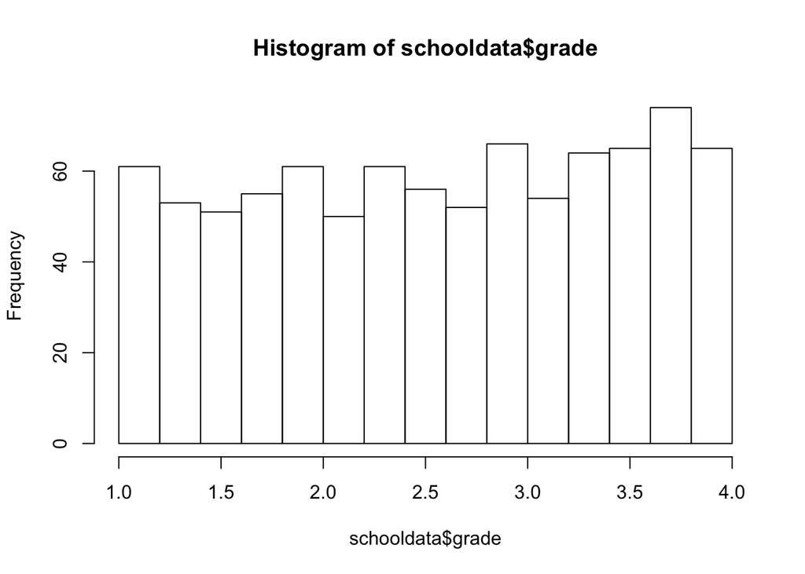

```r
hist(schooldata$grade)
```

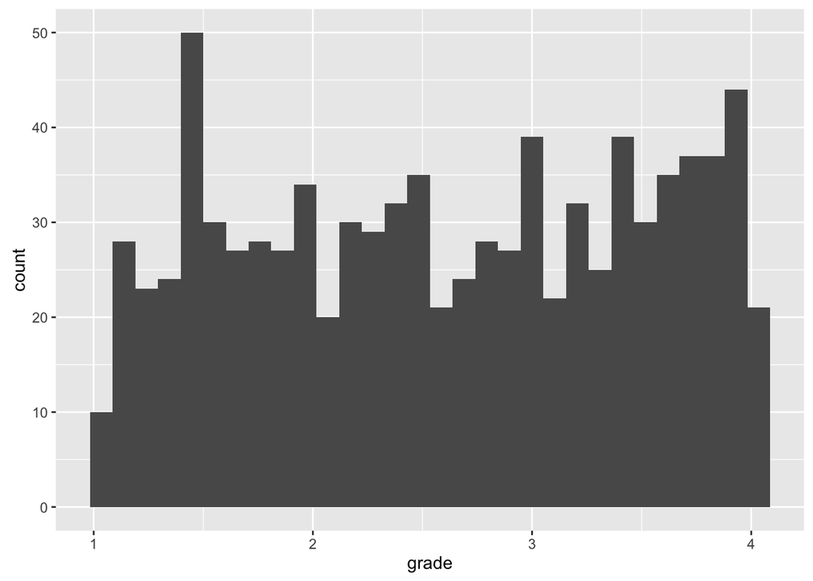

```r
ggplot(schooldata, aes(grade)) + geom_histogram()
```

`ggplot2` works by adding up components of the graph. It starts with a call to `ggplot` specifying which data to use. The first parameter is the name of the data frame, and then in the `aes` function specifies the variables to use. For a histogram, there is just one variable, so you don’t have to specify whether it’s x or y. Then you add on the type of plot you want. In this case, `geom_histogram`.

The call to ``ggplot` gave a message that it was using 30 “bins” – this is the number of histogram bars. You can change this:

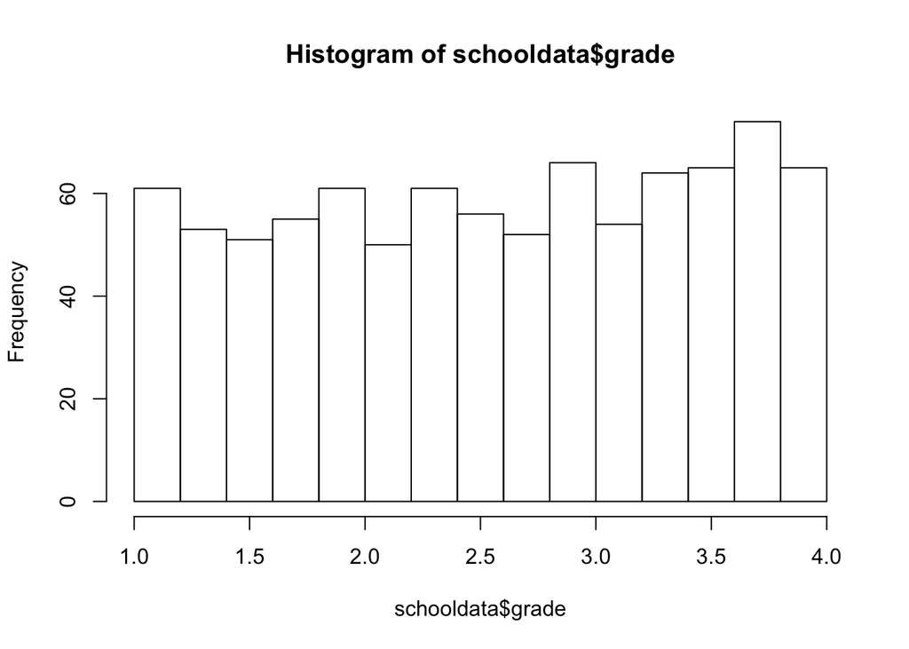

```r
hist(schooldata$grade, breaks=20)
```

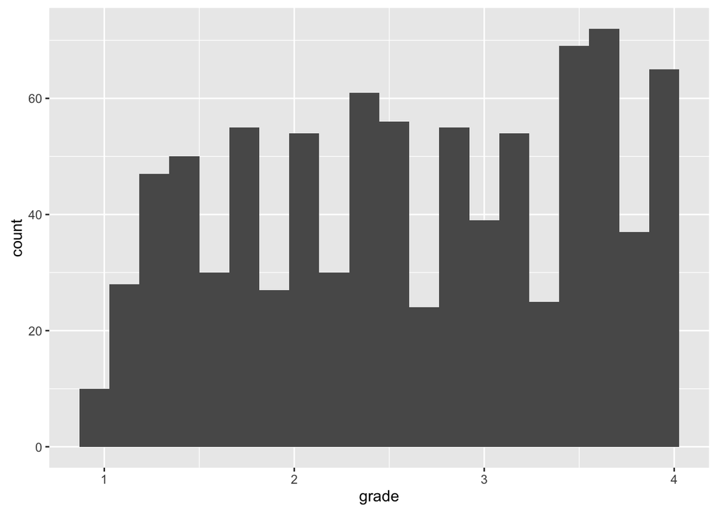

```r
ggplot(schooldata, aes(grade)) + geom_histogram(bins=20)
```

Changing the number of bins (and the cut-offs) makes the pattern in the data look a bit different. Something to be aware of. You can also set the binwidth – say every quarter point here. You can also set the limits of the plot: `NA` in a limit tells ggplot to calculate the upper limit.

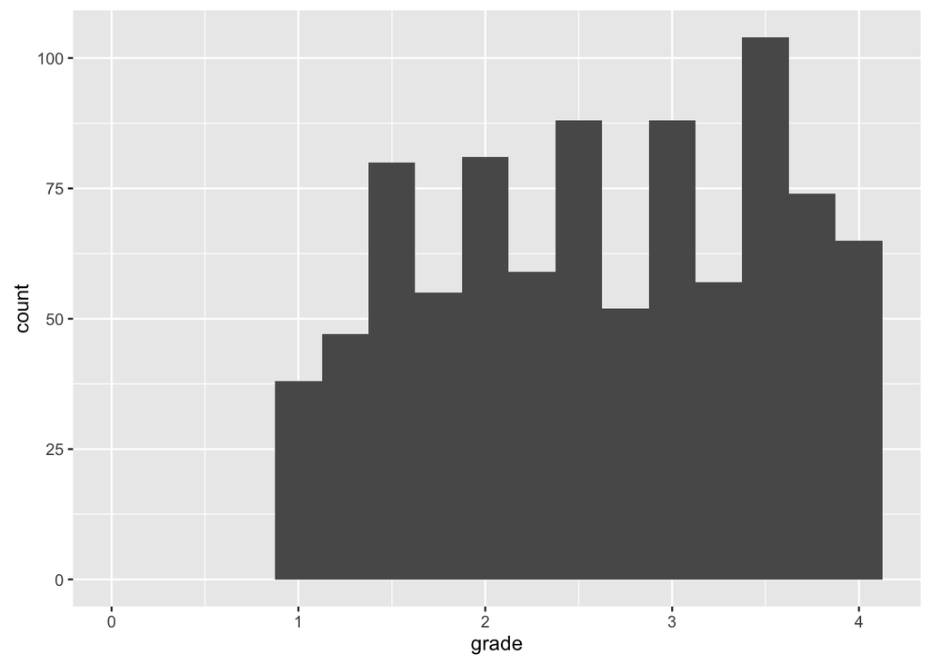

```r
ggplot(schooldata, aes(grade)) + geom_histogram(binwidth=.25) + xlim(0, NA)
```

In the above plot, you can more clearly see that there are a lot of half and whole grades (1.5, 2, 2.5, 3, etc.). `ggplot` created the bins centered around a whole number (integer) by default.

Setting the bin width isn’t as easy with `hist`. You have to specify all of the break points (which can be done with a sequence). To mimic the `ggplot` behavior:

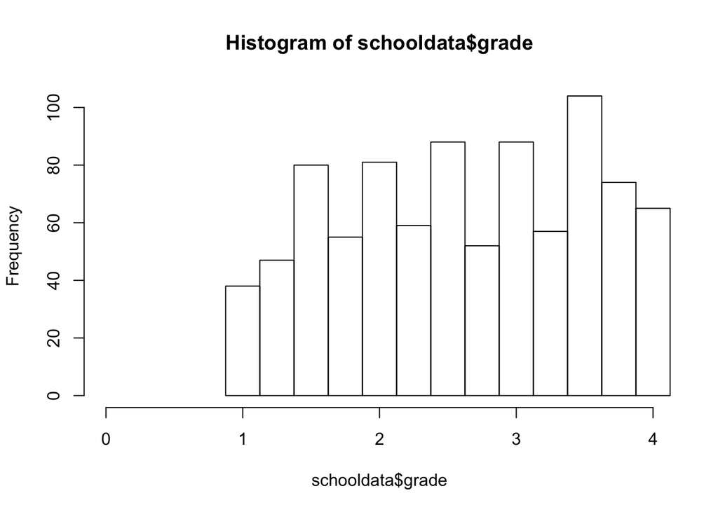

```r
hist(schooldata$grade, breaks=seq(.875, 4.125, .25), xlim=c(0,4))
```

You can also change the axis labels and add a title:

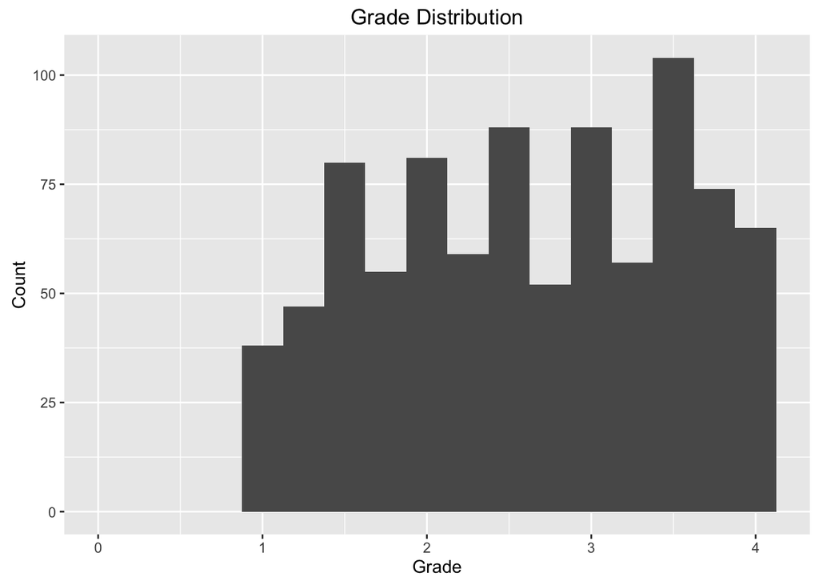

```r
ggplot(schooldata, aes(grade)) + geom_histogram(binwidth=.25) + xlim(0,NA) +
  xlab("Grade") + ylab("Count") + ggtitle("Grade Distribution")
```

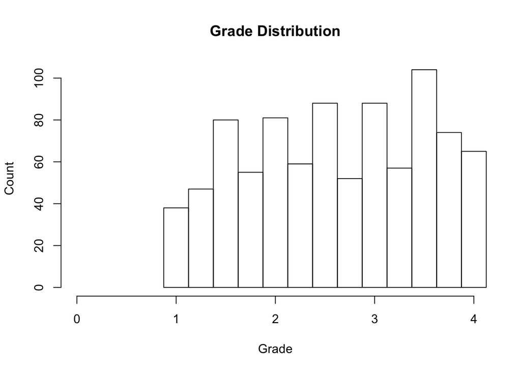

```r
hist(schooldata$grade, breaks=seq(.875, 4.125, .25), xlim=c(0,4), main="Grade Distribution", ylab="Count", xlab="Grade")
```

NOTE: like with `dplyr`, if you’re splitting `ggplot2` commands onto multiple lines, make sure to put the line break after the `+` so that the console knows that more commands are coming that are part of the same plot.

What if you want to see the grade distribution by gender? Add facet grid usign `ggplot`:

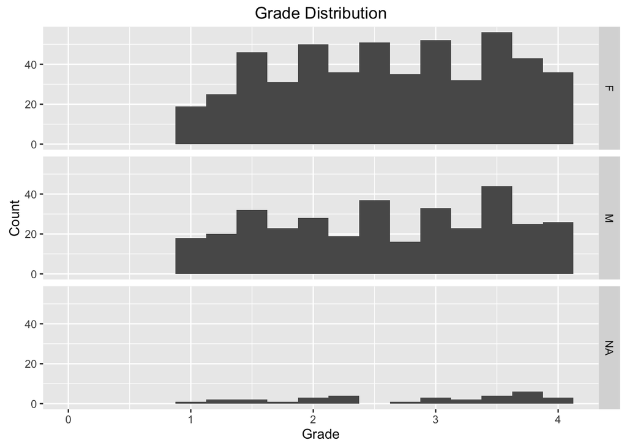

```r
ggplot(schooldata, aes(grade)) + geom_histogram(binwidth=.25) + xlim(0,NA) +
  xlab("Grade") + ylab("Count") + ggtitle("Grade Distribution") + facet_grid(gender~.)
```

It’s possible to do something similar using `hist` and base R graphics, but it’s not simple. Use `ggplot` if this is what you want to do.

Remove the missing category and change the labels by altering the data being plotted. `facet_grid` makes a factor, so change the levels and labels of the factor. For the missing data, exclude it using `dplyr` functions up front:

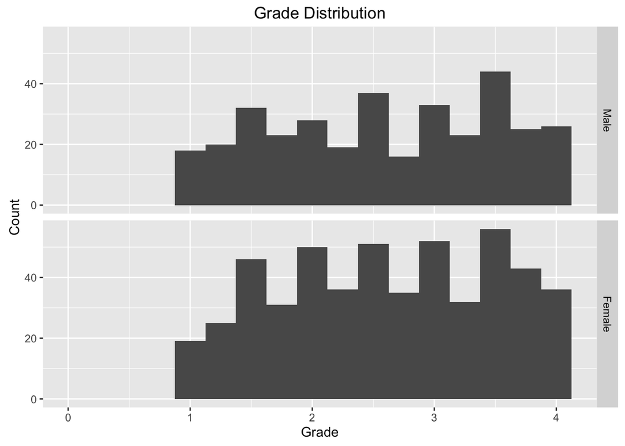

```r
filter(schooldata, !is.na(gender)) %>%
  mutate(gender=factor(gender, levels=c("M", "F"), labels=c("Male","Female"))) %>%
  ggplot(aes(grade)) + geom_histogram(binwidth=.25) + xlim(0,NA) + xlab("Grade") +
  ylab("Count") + ggtitle("Grade Distribution") + facet_grid(gender~.)
```

Without `dplyr`, you could make a new data.frame ahead of time and create the factor. Then run the plot.

## Scatter Plot

How about a scatter plot? Use the `gapminder` data. Look at `gdpPercap` (GDP per capita) vs. `lifeExp` (life expectancy) across countries for the year 2002. First select the data, then send it to the plot:

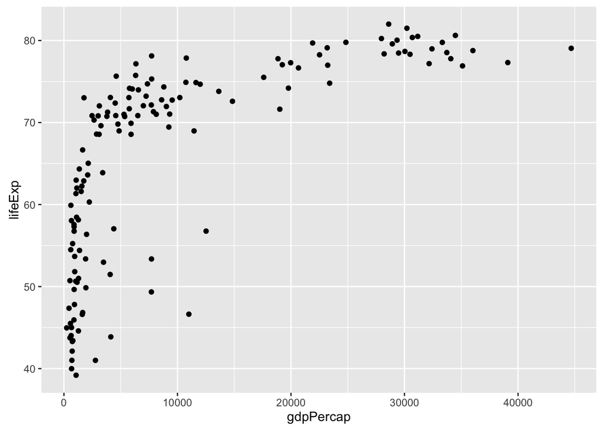

```r
filter(gapminder, year==2002) %>% ggplot(aes(x=gdpPercap, y=lifeExp)) + geom_point()
```

or do this without `dplyr`:

```r
ggplot(gapminder[gapminder$year==2002,], aes(x=gdpPercap, y=lifeExp)) + geom_point()
```

or without `ggplot`:

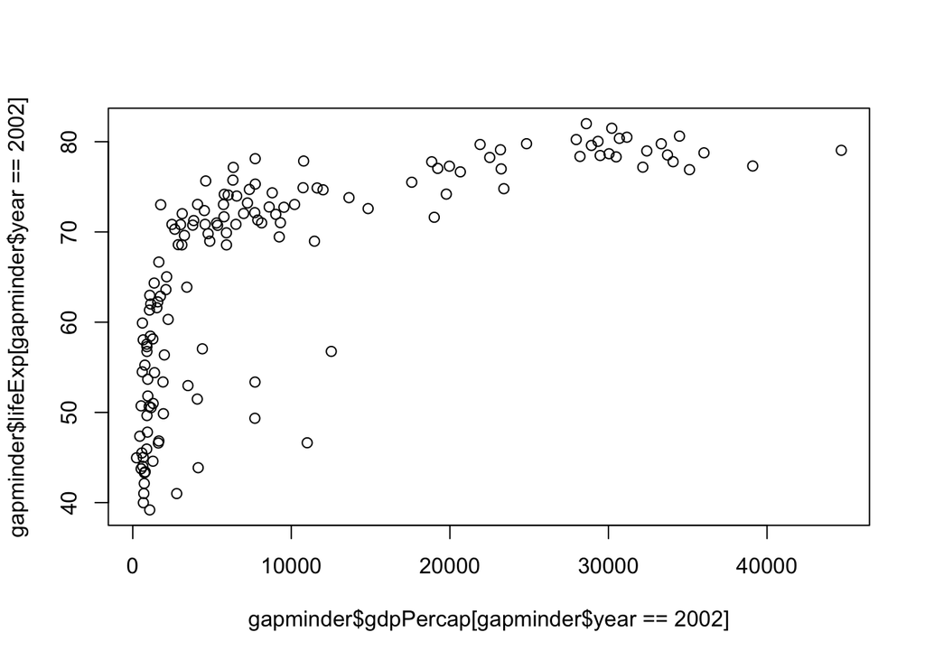

```r
plot(gapminder$gdpPercap[gapminder$year==2002], gapminder$lifeExp[gapminder$year==2002])
```

This looks like a logarithmic relationship. Change the axis (look at the cheatsheet for reference):

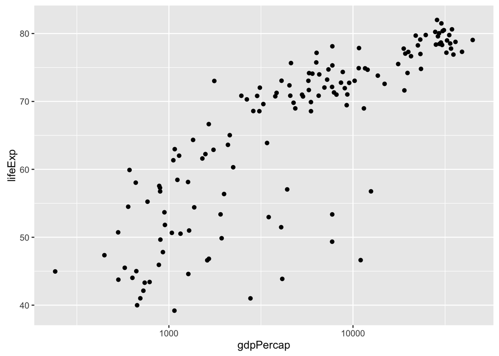

```r
filter(gapminder, year==2002) %>% ggplot(aes(x=gdpPercap, y=lifeExp)) +
  geom_point() + scale_x_log10()
```

Now it looks more like a linear relationship.

Color the points by continent. Specify the color in the `aes` call (it goes in the `aes` call because you’re plotting a variable using color, much as you are plotting other variables using x and y position):

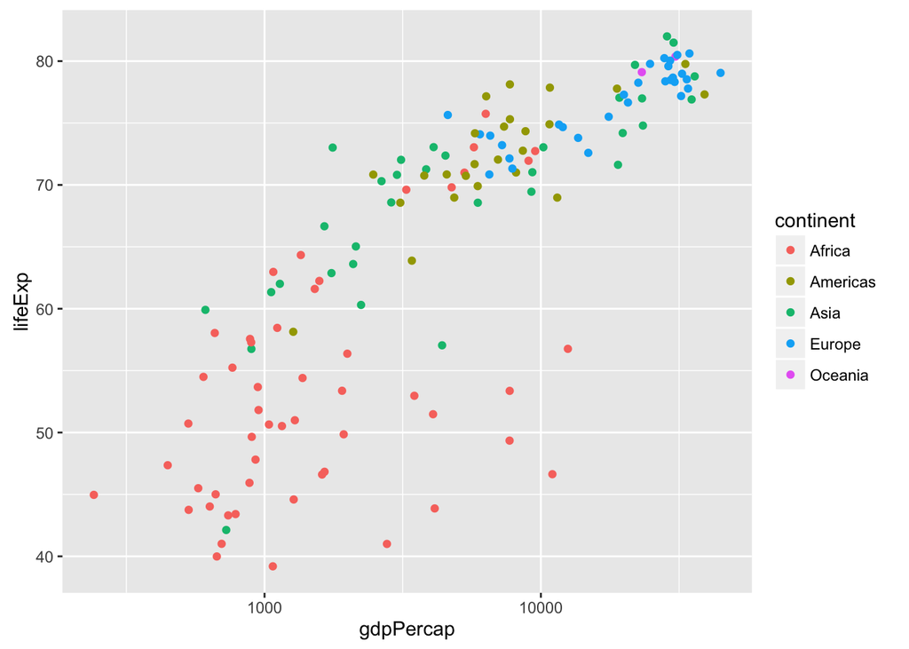

```r
filter(gapminder, year==2002) %>% ggplot(aes(x=gdpPercap, y=lifeExp, color=continent)) +
  geom_point() + scale_x_log10()
```

Instead of using the default colors, you can specify a color palette. Define the set of colors to use first (here using hex color codes), and then set the palette:

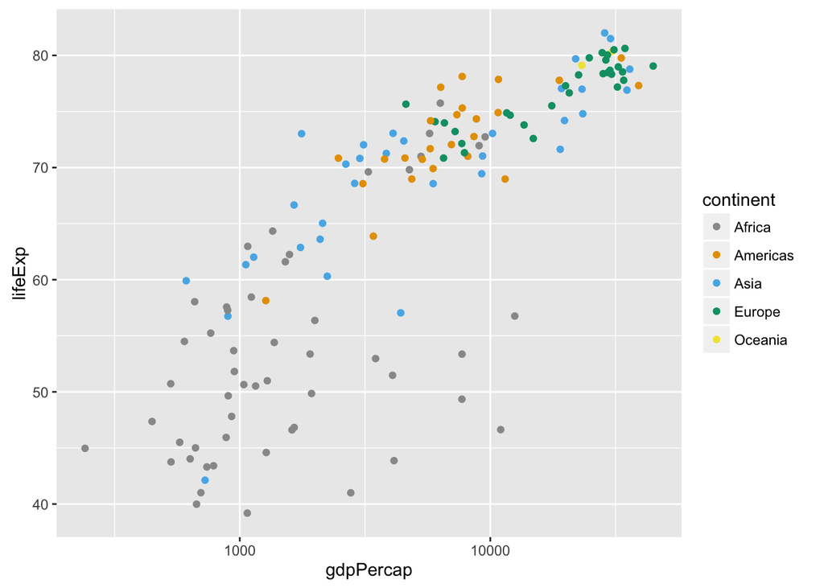

```r
cbPalette <- c("#999999", "#E69F00", "#56B4E9", "#009E73", "#F0E442", "#0072B2", "#D55E00", "#CC79A7")
filter(gapminder, year==2002) %>% ggplot(aes(x=gdpPercap, y=lifeExp, color=continent)) +
  geom_point() + scale_x_log10() + scale_colour_manual(values=cbPalette)
```

The example palette above is a color-blind friendly palette from http://jfly.iam.u-tokyo.ac.jp/color/ (using color-blind friendly colors for publications is a good idea even if you yourself aren’t color blind).

Or use a pre-defined palette:

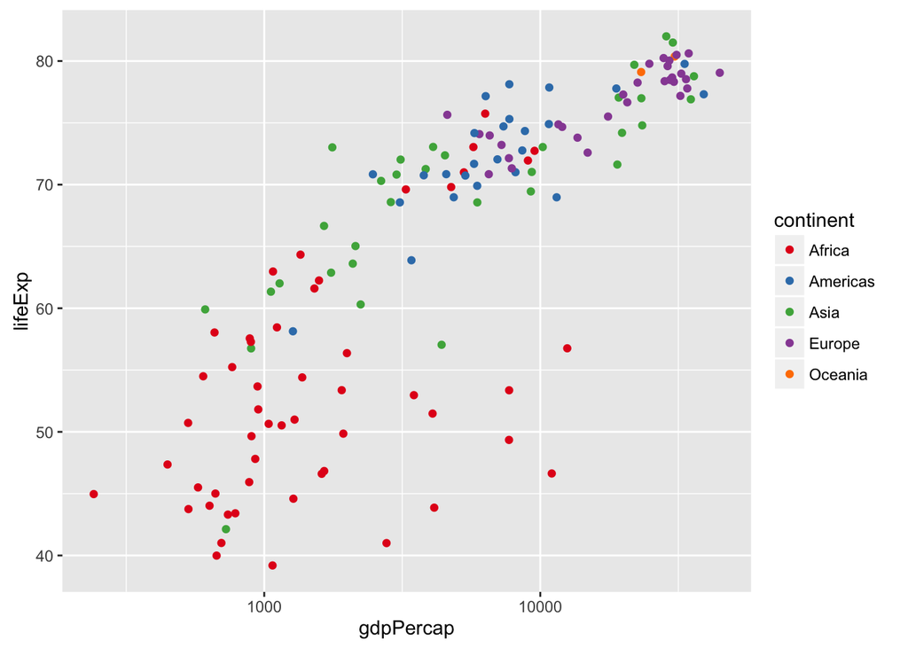

```r
filter(gapminder, year==2002) %>% ggplot(aes(x=gdpPercap, y=lifeExp, color=continent)) +
  geom_point() + scale_x_log10() + scale_colour_brewer(palette = "Set1")
```

How to save the plot? There’s an export button in the plot window, or use the `ggsave` command to save the last plot we made. It will take the file type from the file name.

```r
ggsave("p1.pdf", width=6, height=4)
```

# Probability Distributions

R knows about a lot of probability distributions:

```r
help(Distributions)
```

For each distribution, there are 4 function: dxxx, pxxx, qxxx and rxxx, where xxx is the name for the distribution. Take the normal distribution as an example.

By default, the normal distribution functions use the distribution with mean=0 and standard deviation (sd)=1. You can change these for different variations on the distribution.

## `dnorm`

First, there is a function to get the density of the probability distribution (the [PDF](https://en.wikipedia.org/wiki/Probability_density_function)):

```r
vals<-seq(-4, 4, .2) # this makes a vector with a sequence of numbers from -4 to 4 in it
data.frame(vals=vals, pdf=dnorm(vals))
```

```
##    vals          pdf
## 1  -4.0 0.0001338302
## 2  -3.8 0.0002919469
## 3  -3.6 0.0006119019
## 4  -3.4 0.0012322192
## 5  -3.2 0.0023840882
## 6  -3.0 0.0044318484
## 7  -2.8 0.0079154516
## 8  -2.6 0.0135829692
## 9  -2.4 0.0223945303
## 10 -2.2 0.0354745928
## 11 -2.0 0.0539909665
## 12 -1.8 0.0789501583
## 13 -1.6 0.1109208347
## 14 -1.4 0.1497274656
```

[output cut: 27 more lines]

Looking at the data, the pdf peaks at 0 (the mean), and decreases symetrically away from 0. Plot this:

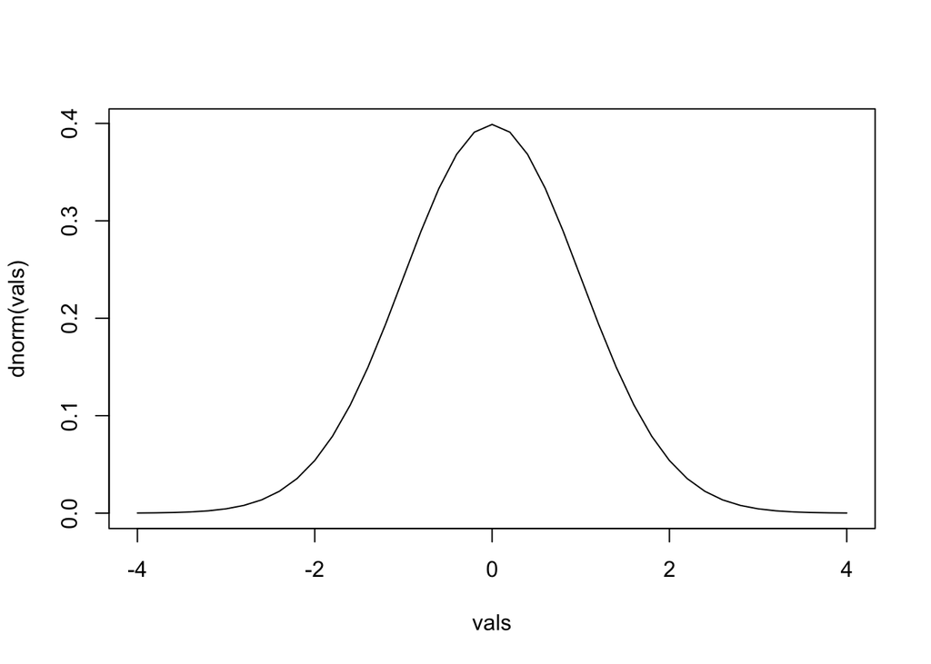

```r
plot(dnorm(vals) ~ vals, type="l")
```

It looks like what you expect for the normal distribution. `dnorm` is mostly commonly used for drawing the distribution – you don’t usually need to compute the value of the PDF at a specific point otherwise.

## `pnorm`

`pnorm` tells us how likely it is (the probability) that a random draw from the distribution would be a value less than or equal to the number supplied – this is the area under the PDF curve. The return value will range between 0 and 1:

```r
vals<-seq(-3,3,.2)
data.frame(vals=vals, prob=pnorm(vals))
```

```
##    vals        prob
## 1  -3.0 0.001349898
## 2  -2.8 0.002555130
## 3  -2.6 0.004661188
## 4  -2.4 0.008197536
## 5  -2.2 0.013903448
## 6  -2.0 0.022750132
## 7  -1.8 0.035930319
## 8  -1.6 0.054799292
## 9  -1.4 0.080756659
## 10 -1.2 0.115069670
## 11 -1.0 0.158655254
## 12 -0.8 0.211855399
## 13 -0.6 0.274253118
## 14 -0.4 0.344578258
```

[output cut: 17 more lines]

It’s always increasing (since as you move right on the number line you’re always increasing the probability that a random draw would be less than or equal to the value), and `pnorm(0)` is 0.5 – since there’s a 50/50 chance that a random draw would be to the left of the mean. If you plot the results of `pnorm`, you get the [CDF](https://en.wikipedia.org/wiki/Cumulative_distribution_function):

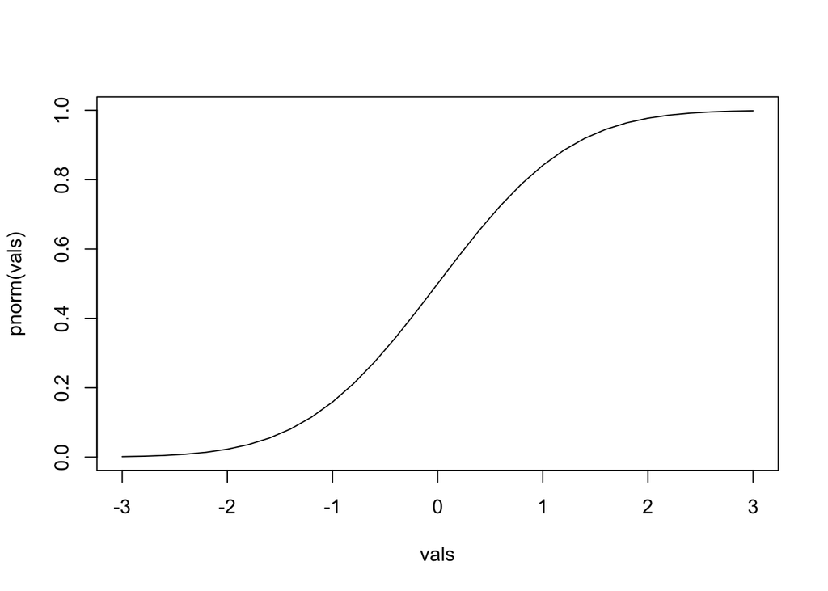

```r
plot(pnorm(vals)~vals, type="l")
```

You would use pnorm when looking up the probability of getting a particular value (such as a test statistic that follows a normal distribution). You can get the probability of a random draw being to the right of the specified value instead with `lower.tail`:

```r
pnorm(1.6)
pnorm(1.6, lower.tail=FALSE)
```

```
## [1] 0.9452007
## [1] 0.05479929
```

## `qnorm`

`qnorm` is the opposite of `pnorm` – it tells you what value you need such that you have the supplied probability of a random draw being less than or equal to (to the left of) that value from the distribution. For example, if you want to know what value you need such that there’s a 95% chance that a random draw would be less than or equal to the number:

```r
qnorm(0.95)
```

```
## [1] 1.644854
```

You need a value of 1.64. Random draws from a normal distribution with mean=0 and standard deviation=1 will be less than or equal to 1.64 95% of the time.

The value you supply to `qnorm` must be between 0 and 1. There’s no limit on the range of the return value.

Again, `pnorm` and `qnorm` are opposites:

```r
qnorm(pnorm(2))
pnorm(qnorm(.8))
```

```
## [1] 2
## [1] 0.8
```

## `rnorm`

The last function is to generate random draws from the distribution. Tell it how many random draws you want:

```r
rnorm(10)
```

```
##  [1]  0.7796219  1.4557851 -0.6443284 -1.5531374 -1.5977095  1.8050975
##  [7] -0.4816474  0.6203798  0.6121235 -0.1623110
```

If you want to make sure we get the same sequence of random numbers each time (or as someone else), you can set the seed with any integer value:

```r
set.seed(12345)
rnorm(10)
```

```
##  [1]  0.5855288  0.7094660 -0.1093033 -0.4534972  0.6058875 -1.8179560
##  [7]  0.6300986 -0.2761841 -0.2841597 -0.9193220
```

This is useful for running simulations when you need to sample from a distribution.

# Resources

Software Carpentry: [R for Reproducible Scientific Analysis](http://swcarpentry.github.io/r-novice-gapminder): course material for introductory R workshop

[R for Data Science](http://r4ds.had.co.nz/): free online book

[RStudio Cheat Sheets](https://www.rstudio.com/resources/cheatsheets/)

[DataCamp](http://datacamp.com): Intro to R course is free

[Swirl](http://swirlstats.com/): Interactive tutorials that you run in R

[UCLA Institute for Digital Research and Education](http://www.ats.ucla.edu/stat/dae/): statistical analysis examples in various statistical software programs, including R

[Quick R](http://www.statmethods.net/index.html): code snippets covering commonly used functions and tasks

[Stack Overflow](http://stackoverflow.com/): great for searching for issues; most questions you have will have already been asked by someone else